# tesshy::www

# キャンピングカー制作日誌::2019-04-14

Tetsushi Watanabe

2019-04-14 12:01

ソース

さて、だいぶ空いてしまったが、10連休に向けてベットを改めようと思う。

納車直後、旅行に間にあわせるためにLアングルを渡してその上にコンパネ置くという荒技でベットに仕立てた。

> [2018/07/30 作業記録](https://www.instagram.com/p/Bl6a3geg6Rv/?utm_source=ig_embed)

> [Tetsushi Watanabe](https://www.instagram.com/tesshy/?utm_source=ig_embed)さん(@tesshy)がシェアした投稿 - 2018年 7月月31日午後3時28分PDT

布団引けばそれなりに寝られるんだが、やっぱり寝にく&不安定。。。

んなもんで、本格的なベットを設置しようと昨年末から考えていた。んが、三人めのお子様誕生などが重なり作業停滞（というかそれどころじゃなかったという面もあり・・・）。しかしGWに間にあわせるために一念発起。

んで「本格的なベット」なのだが、当初は「ガチでフレーム組んでスプリングマットレス載せる」という方針だった。が、実際考えると木材で組むにしても手間かかりすぎてめんどくセーなー、という怠惰な結論に到り、どうしたもんかなと。そんで無印のホームページ見てたら・・・あるじゃないですか、

「脚付きマットレス」

という素晴らしい一品が！もうスペースは潤沢にあるんだから、脚付きマットレスそのまま載せればええやん、と。そうとなったら車内の幅を確認。

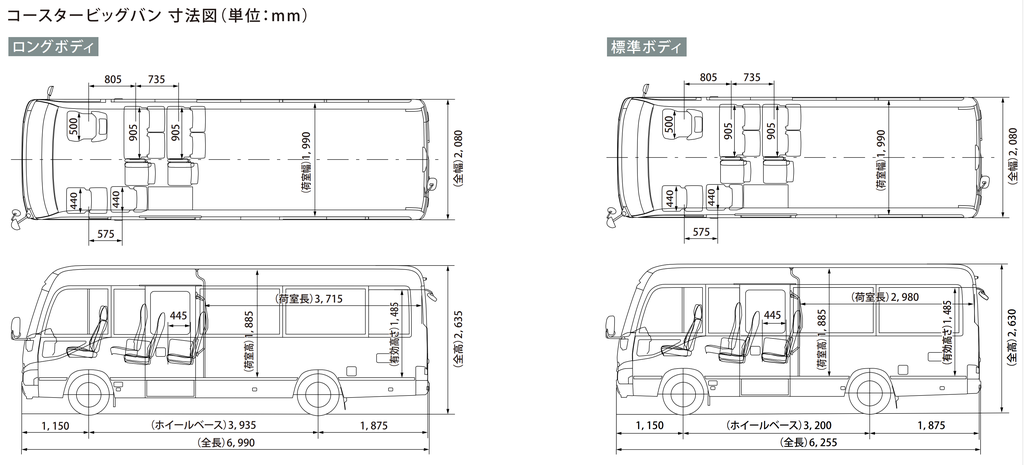

https://toyota.jp/pages/contents/coaster/005_b_002/pdf/spec/coaster_bigvan_spec_201806.pdf

幅は1990、但し、これどうも内装無視して最も広く取れるスペースらしく、実寸でいいとこ1800。これに会う脚付きマットレスを探した。実際設置するとなると1枚モノはしんどいので、シングルを2枚使うことに。というわけで理想は900幅のモノ。

結論として、国内ブランドのものはどれもビミョーな幅で、そのものズバリな幅のモノがIKEAのこれ。

[figure not shown]

[SNARUM スナルム](https://www.ikea.com/jp/ja/catalog/products/30307348/)

素晴らしきかな、2000x900という理想のサイズ！お値段もそこまでお高く無いのでグー。そうとなったら買いに行くわけです、IKEA新三郷に。

[interactive chart not shown]

新三郷、うちから一番近いというのもあるが、何が素晴らしいって中型車用駐車スペースがあること！うちは毎度コースターに行って中型専用スペースに停めさせていただいております、感謝。（ついでに言うと最近隣のコストコにガソリンスタンドができたので軽油がめっちゃ安く入れられる点がGood、コストコ店舗は休日は死ぬほど混んでるので近づかない・・・）

というわけでベットは入手できたものの、実は脚が20cmのものしかなく、これでは後輪のハウジングに当たってしまう。（わかってたよ！ほんとだよ！！）というわけで脚を自作することに。ネジ自体はM8の50mmっぽいので、それに合わせたハンガーボルトを購入。

[figure not shown]

（こんなのでいいかと。某はジョイフル本田で売ってた真鍮メッキのやつ買ったけど値段は大して変わらず）

そんで脚本体だが、、、最初は垂木でいいだろとか思ってたが、実際現物見てみると結構反っとる・・・。というかこれ時間経つともっと反るな・・・・などと怪しい空気がプンプンしてたので一旦ペンディング。。。

と言うわけで、脚材に関しては次の回にて。

Share